# Презентация по лабораторной работе №1.

Дисциплина: Операционные системы.

Лобанова П. И.

Российский университет дружбы народов, Москва, Россия.

Факультет физико-математических и естественных наук.

17.02.2023

# Информация

## Докладчик

- Лобанова Полина Иннокентьевна
- Студентка факультета физико-математических и естественных наук
- Учащаяся на направлении “Математика и механика”
- Российский университет дружбы народов
- polla-2004@mail.ru

# Цель лабораторной работы

Целью данной работы является приобретение практических навыков установки операционной системы на виртуальную машину, настройки минимально необходимых для дальнейшей работы сервисов.

# Ход работы

## Установка VirtualBox, создание и настройка виртуальной машины.

На первом этапе необходимо создать виртуальную машину с операционной системой Linux, а также произвести некоторые настройки, такие как создание нового жесткого диска, выбор его типа, формата и размера, выбор объема видеопамяти и тд.

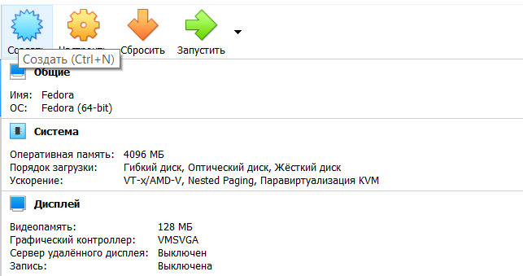

*Создание виртуальной машины.*

## Настройка операционной системы

Далее было необходимо провести базовые настройки (время, язык и тд) и создать учетную запись, а так произвести обновление всех пакетов и установку программы для удобства работы в консоли.

[figure not shown]

*Выбор часового пояса.*

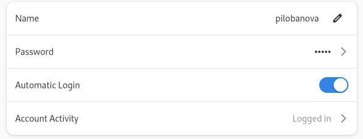

*Создание учетной записи.*

## Настройка расскладки

Далее нужно было настроить раскладку клавиатуры.

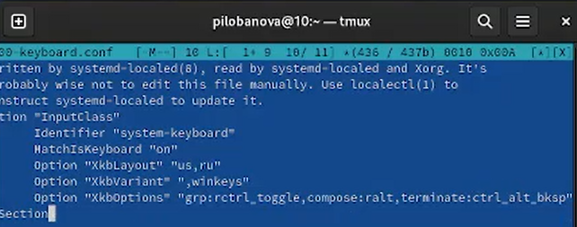

*Настройка раскладки клавиатуры.*

## Установка программного обеспечения для создания документации

Далее мне необходимо было установить pandoc и texlive.

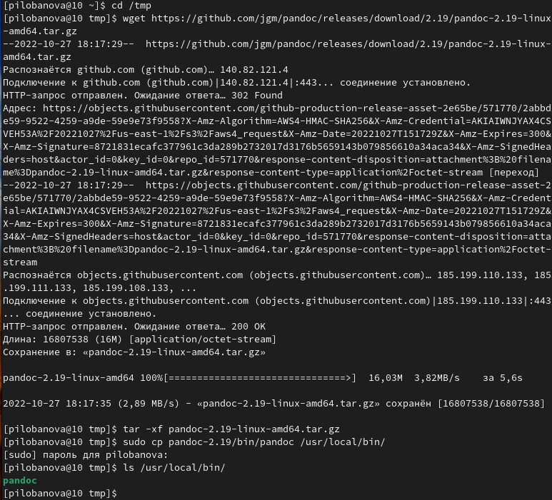

*Установка pandoc.*

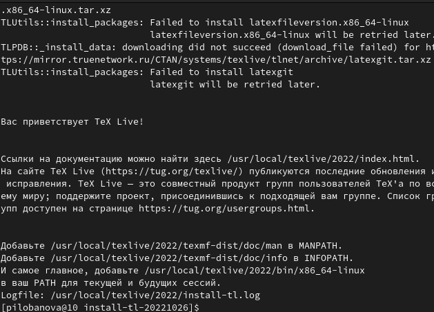

*Установка texlive.*

## Выполнение домашнего задания

В качестве домашнего задания мне было необходимо узнать следующую информацию: Версия ядра Linux (Linux version). Частота процессора (Detected Mhz processor). Модель процессора (CPU0). Объём доступной оперативной памяти (Memory available). Тип обнаруженного гипервизора (Hypervisor detected). Тип файловой системы корневого раздела. Последовательность монтирования файловых систем.

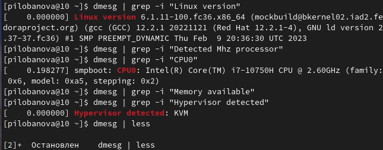

## Контрольные вопросы

Какую информацию содержит учётная запись пользователя?

Укажите команды терминала и приведите примеры:

для получения справки по команде; для перемещения по файловой системе; для просмотра содержимого каталога; для определения объёма каталога; для создания / удаления каталогов / файлов; для задания определённых прав на файл / каталог; для просмотра истории команд. Что такое файловая система? Приведите примеры с краткой характеристикой.

Как посмотреть, какие файловые системы подмонтированы в ОС? Как удалить зависший процесс?

# Вывод

Я научилась устанавливать операционные системы на виртуальную машину и настраивать сервисы, необходимые для работы.